# Tugas 1 MPDW

G1401211038_Dhiya Khalishah Tsany Suwarso

2023-09-04

#Memanggil library yang akan dipakai

```r
library("forecast")
```

```r
library("graphics")
library("TTR")
library("TSA")
```

#Impor data

```r
library(readxl)
data <- read_excel("E:/kuliah/Semester 5/Metode Peramalan Deret Waktu/appleStockPrice.xlsx")
```

#Eksplorasi data Melihat data, struktur data, dan dimensi data

```r
View(data)
str(data)
```

```
## tibble [822 × 2] (S3: tbl_df/tbl/data.frame)
##  $ Tanggal       : POSIXct[1:822], format: "2007-01-12" "2007-01-19" ...
##  $ Harga_Mingguan: num [1:822] 3.38 3.16 3.05 3.03 2.97 ...
```

```r
dim(data)
```

```
## [1] 822   2
```

Mengubah data agar terbaca sebagai data deret waktu

```r
data.ts <- ts(data$Harga_Mingguan)
```

Menampilkan ringkasan data

```r
summary(data.ts)
```

```
##    Min. 1st Qu.  Median    Mean 3rd Qu.    Max.
##    2.94   11.45   24.49   41.15   47.19  179.45
```

Membuat plot data deret waktu

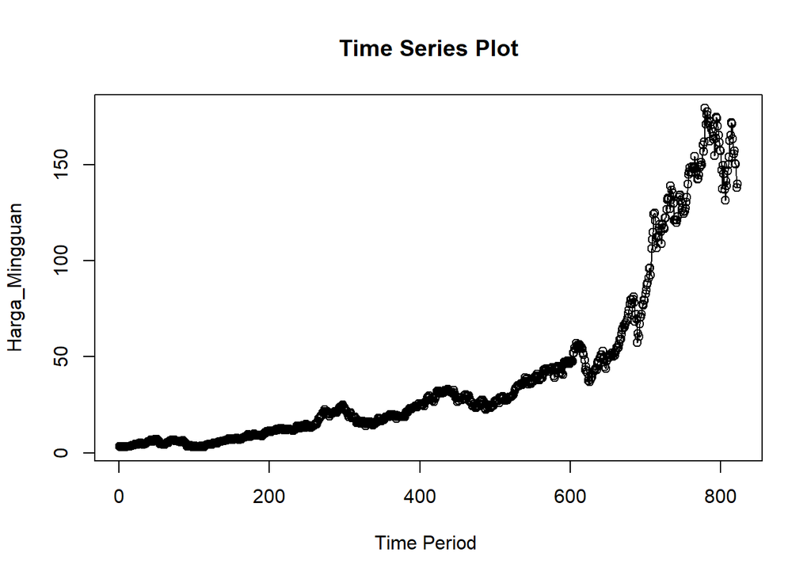

```r
ts.plot(data.ts, xlab="Time Period ", ylab="Harga_Mingguan",
        main = "Time Series Plot")
points(data.ts)
```

#Single Moving Average & Double Moving Average Membagi data train (80%) dan data test (20%)

```r
training <- data[1:658,]
testing <- data[659:822,]
training.ts <- ts(training$Harga_Mingguan)
test.ts <- ts(testing$Harga_Mingguan)
```

Eksplorasi data train dan data test menggunakan plot data deret waktu

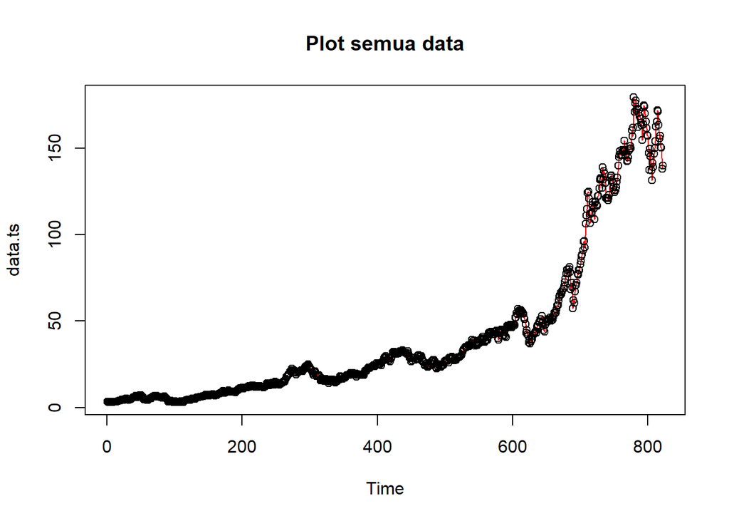

```r
#eksplorasi keseluruhan data
plot(data.ts, col="red",main="Plot semua data")
points(data.ts)
```

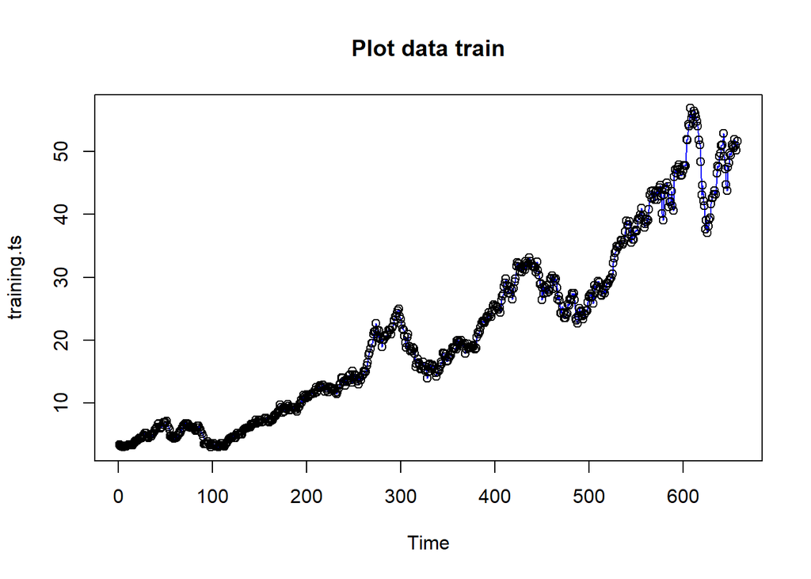

```r
#eksplorasi data train
plot(training.ts, col="blue",main="Plot data train")
points(training.ts)
```

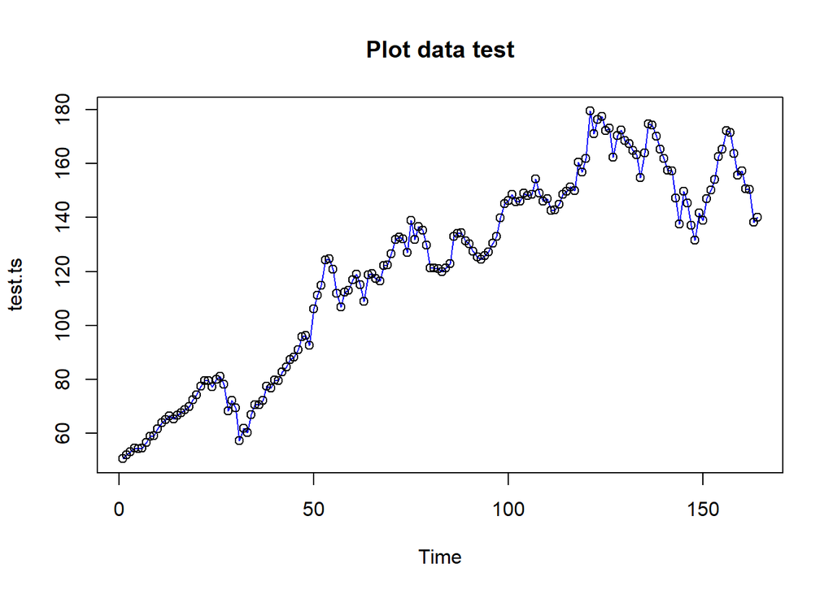

```r
#eksplorasi data test
plot(test.ts, col="blue",main="Plot data test")
points(test.ts)
```

Eksplorasi data juga dapat dilakukan menggunakan package `ggplot2`

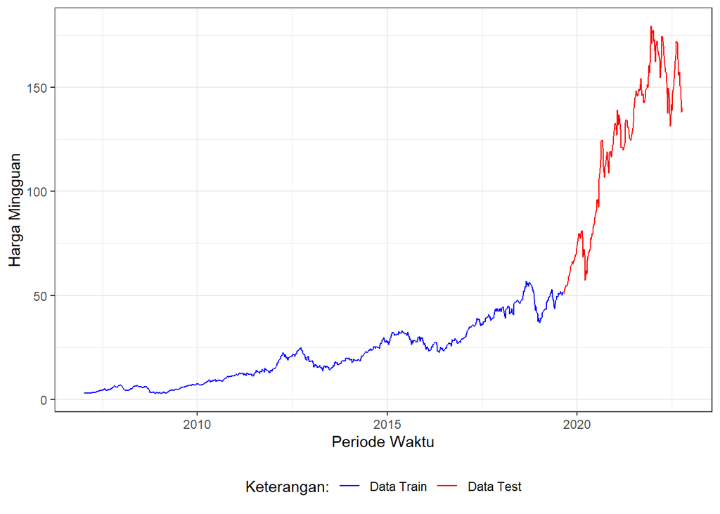

```r
library(ggplot2)
ggplot() +
  geom_line(data = training, aes(x = Tanggal, y = Harga_Mingguan, col = "Data Train")) +
  geom_line(data = testing, aes(x = Tanggal, y = Harga_Mingguan, col = "Data Test")) +
  labs(x = "Periode Waktu", y = "Harga Mingguan", color = "Legend") +
  scale_colour_manual(name="Keterangan:", breaks = c("Data Train", "Data Test"),
                      values = c("blue", "red")) +
  theme_bw() + theme(legend.position = "bottom",
                     plot.caption = element_text(hjust=0.5, size=12))
```

## Single Moving Average (SMA) Single Moving Average (SMA) adalah data suatu periode dipengaruhi oleh data periode sebelumnya. Prinsip dasar metode pemulusan ini adalah data pemulusan pada periode ke-t merupakan rata rata dari m buah data pada periode ke-t hingga periode ke (t-m+1). Data pemulusan pada periode ke-t selanjutnya digunakan sebagai nilai peramalan pada periode ke t+1

Pemulusan menggunakan metode SMA dilakukan dengan fungsi `SMA()`. Dalam hal ini akan dilakukan pemulusan dengan parameter `m=4`.

```r
data.sma<-SMA(training.ts, n=4)
data.sma
```

```
## Time Series:
## Start = 1
## End = 658
## Frequency = 1
##   [1]        NA        NA        NA  3.154018  3.052679  3.019911  3.052857
##   [8]  3.058750  3.100714  3.143214  3.182946  3.249911  3.309821  3.315625
##  [15]  3.292857  3.355446  3.410178  3.575357  3.745446  3.867768  4.024821
##  [22]  4.165446  4.259017  4.342767  4.375267  4.445000  4.598839  4.784107
##  [29]  4.978839  4.974822  4.861161  4.667500  4.591161  4.650357  4.710804
##  [36]  4.860357  4.939375  5.073214  5.338214  5.592143  5.826696  6.105536
##  [43]  6.341429  6.324643  6.288661  6.171161  6.120714  6.379018  6.593304
##  [50]  6.793036  6.950268  6.823036  6.665000  6.374375  5.750982  5.337589
##  [57]  4.916072  4.588125  4.493929  4.415982  4.387143  4.404821  4.528125
##  [64]  4.688750  4.964018  5.147321  5.395268  5.633839  5.882589  6.206786
##  [71]  6.444107  6.546250  6.615982  6.635535  6.499375  6.446696  6.280089
```

[output cut: 83 more lines]

Data pemulusan pada periode ke-t selanjutnya digunakan sebagai nilai peramalan pada periode ke t+1 sehingga hasil peramalan 1 periode kedepan adalah sebagai berikut.

```r
data.ramal<-c(NA,data.sma)
data.ramal #forecast 1 periode ke depan
```

```
##   [1]        NA        NA        NA        NA  3.154018  3.052679  3.019911
##   [8]  3.052857  3.058750  3.100714  3.143214  3.182946  3.249911  3.309821
##  [15]  3.315625  3.292857  3.355446  3.410178  3.575357  3.745446  3.867768
##  [22]  4.024821  4.165446  4.259017  4.342767  4.375267  4.445000  4.598839
##  [29]  4.784107  4.978839  4.974822  4.861161  4.667500  4.591161  4.650357
##  [36]  4.710804  4.860357  4.939375  5.073214  5.338214  5.592143  5.826696
##  [43]  6.105536  6.341429  6.324643  6.288661  6.171161  6.120714  6.379018
##  [50]  6.593304  6.793036  6.950268  6.823036  6.665000  6.374375  5.750982
##  [57]  5.337589  4.916072  4.588125  4.493929  4.415982  4.387143  4.404821
##  [64]  4.528125  4.688750  4.964018  5.147321  5.395268  5.633839  5.882589
##  [71]  6.206786  6.444107  6.546250  6.615982  6.635535  6.499375  6.446696
##  [78]  6.280089  6.141518  6.143393  6.053035  5.981875  5.861696  5.834643
##  [85]  5.929196  6.060179  6.175089  6.091429  5.852143  5.531786  5.163125
##  [92]  4.599643  4.134107  3.745625  3.461161  3.555089  3.567946  3.504018
##  [99]  3.380803  3.247589  3.209732  3.281429  3.347679  3.286429  3.257411
```

[output cut: 80 more lines]

Selanjutnya akan dilakukan peramalan sejumlah data test yaitu 164 periode. Pada metode SMA, hasil peramalan 164 periode ke depan akan bernilai sama dengan hasil peramalan 1 periode kedepan. Dalam hal ini akan dilakukan pengguabungan data aktual train, data hasil pemulusan dan data hasil ramalan 164 periode kedepan.

```r
data.gab<-cbind(aktual=c(training.ts,rep(NA,164)),pemulusan=c(data.sma,rep(NA,164)),ramalan=c(data.ramal,rep(data.ramal[length(data.ramal)],163)))
data.gab #forecast 164 periode ke depan
```

```
##           aktual pemulusan   ramalan
##   [1,]  3.379286        NA        NA
##   [2,]  3.160714        NA        NA
##   [3,]  3.049286        NA        NA
##   [4,]  3.026786  3.154018        NA
##   [5,]  2.973929  3.052679  3.154018
##   [6,]  3.029643  3.019911  3.052679
##   [7,]  3.181071  3.052857  3.019911
##   [8,]  3.050357  3.058750  3.052857
##   [9,]  3.141786  3.100714  3.058750
##  [10,]  3.199643  3.143214  3.100714
##  [11,]  3.340000  3.182946  3.143214
##  [12,]  3.318214  3.249911  3.182946
##  [13,]  3.381429  3.309821  3.249911
##  [14,]  3.222857  3.315625  3.309821
```

[output cut: 808 more lines]

Adapun plot data deret waktu dari hasil peramalan yang dilakukan adalah sebagai berikut.

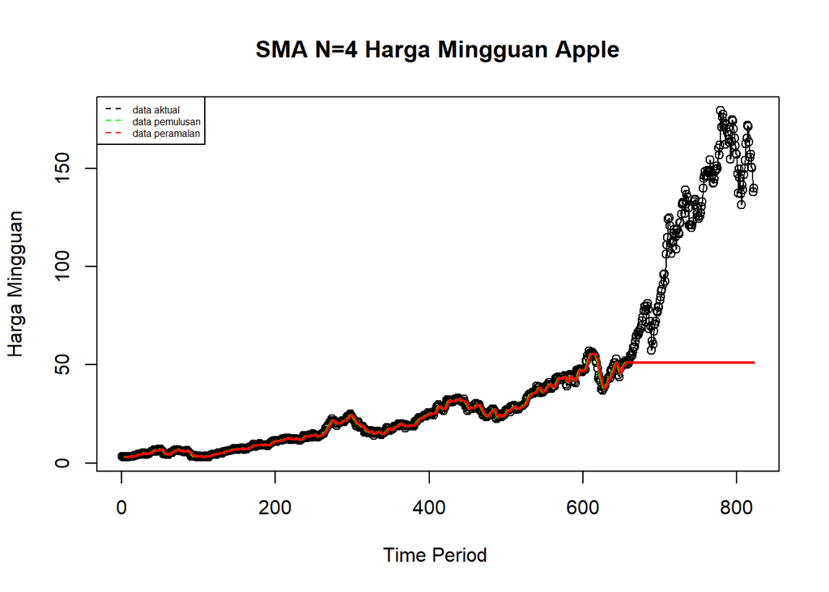

```r
ts.plot(data.ts, xlab="Time Period ", ylab="Harga Mingguan", main= "SMA N=4 Harga Mingguan Apple")
points(data.ts)
lines(data.gab[,2],col="green",lwd=2)
lines(data.gab[,3],col="red",lwd=2)
legend("topleft",c("data aktual","data pemulusan","data peramalan"), lty=8, col=c("black","green","red"), cex=0.5)
```

Selanjutnya perhitungan akurasi dilakukan dengan ukuran akurasi *Sum Squares Error* (SSE), *Mean Square Error* (MSE) dan *Mean Absolute Percentage Error* (MAPE). Perhitungan akurasi dilakukan baik pada data train maupun pada data test.

```r
#Menghitung nilai keakuratan data train
error_train.sma = training.ts-data.ramal[1:length(training.ts)]
SSE_train.sma = sum(error_train.sma[5:length(training.ts)]^2)
MSE_train.sma = mean(error_train.sma[5:length(training.ts)]^2)
MAPE_train.sma = mean(abs((error_train.sma[5:length(training.ts)]/training.ts[5:length(training.ts)])*100))

akurasi_train.sma <- matrix(c(SSE_train.sma, MSE_train.sma, MAPE_train.sma))
row.names(akurasi_train.sma)<- c("SSE", "MSE", "MAPE")
colnames(akurasi_train.sma) <- c("Akurasi m = 4")
akurasi_train.sma
```

```
##      Akurasi m = 4
## SSE    1095.351926
## MSE       1.674850
## MAPE      4.724965
```

```r
#Menghitung nilai keakuratan data test
error_test.sma = test.ts-data.gab[659:822,3]
SSE_test.sma = sum(error_test.sma^2)
MSE_test.sma = mean(error_test.sma^2)
MAPE_test.sma = mean(abs((error_test.sma/test.ts*100)))

akurasi_test.sma <- matrix(c(SSE_test.sma, MSE_test.sma, MAPE_test.sma))
row.names(akurasi_test.sma)<- c("SSE", "MSE", "MAPE")
colnames(akurasi_test.sma) <- c("Akurasi m = 4")
akurasi_test.sma
```

```
##      Akurasi m = 4
## SSE   1.021987e+06
## MSE   6.231628e+03
## MAPE  5.226476e+01
```

## Double Moving Average (DMA)

Metode pemulusan Double Moving Average (DMA) pada dasarnya mirip dengan SMA. Namun demikian, metode ini lebih cocok digunakan untuk pola data trend. Proses pemulusan dengan rata rata dalam metode ini dilakukan sebanyak 2 kali.

```r
dma <- SMA(data.sma, n = 4)
At <- 2*data.sma - dma
Bt <- 2/(4-1)*(data.sma - dma)
data.dma<- At+Bt
data.ramal2<- c(NA, data.dma)

t = 1:164
f = c()

for (i in t) {
  f[i] = At[length(At)] + Bt[length(Bt)]*(i)
}

data.gab2 <- cbind(aktual = c(training.ts,rep(NA,164)), pemulusan1 = c(data.sma,rep(NA,164)),pemulusan2 = c(data.dma, rep(NA,164)),At = c(At, rep(NA,164)), Bt = c(Bt,rep(NA,164)),ramalan = c(data.ramal2, f[-1]))
data.gab2
```

```
##           aktual pemulusan1 pemulusan2        At            Bt   ramalan
##   [1,]  3.379286         NA         NA        NA            NA        NA
##   [2,]  3.160714         NA         NA        NA            NA        NA
##   [3,]  3.049286         NA         NA        NA            NA        NA
##   [4,]  3.026786   3.154018         NA        NA            NA        NA
##   [5,]  2.973929   3.052679         NA        NA            NA        NA
##   [6,]  3.029643   3.019911         NA        NA            NA        NA
##   [7,]  3.181071   3.052857   3.024509  3.035848 -0.0113393333        NA
##   [8,]  3.050357   3.058750   3.079918  3.071451  0.0084671667  3.024509
##   [9,]  3.141786   3.100714   3.171808  3.143370  0.0284374167  3.079918
##  [10,]  3.199643   3.143214   3.233765  3.197545  0.0362202083  3.171808
##  [11,]  3.340000   3.182946   3.285514  3.244487  0.0410268333  3.233765
##  [12,]  3.318214   3.249911   3.384435  3.330625  0.0538095417  3.285514
##  [13,]  3.381429   3.309821   3.457069  3.398170  0.0588988333  3.384435
##  [14,]  3.222857   3.315625   3.400707  3.366674  0.0340327083  3.457069
```

[output cut: 808 more lines]

Hasil pemulusan menggunakan metode DMA divisualisasikan sebagai berikut

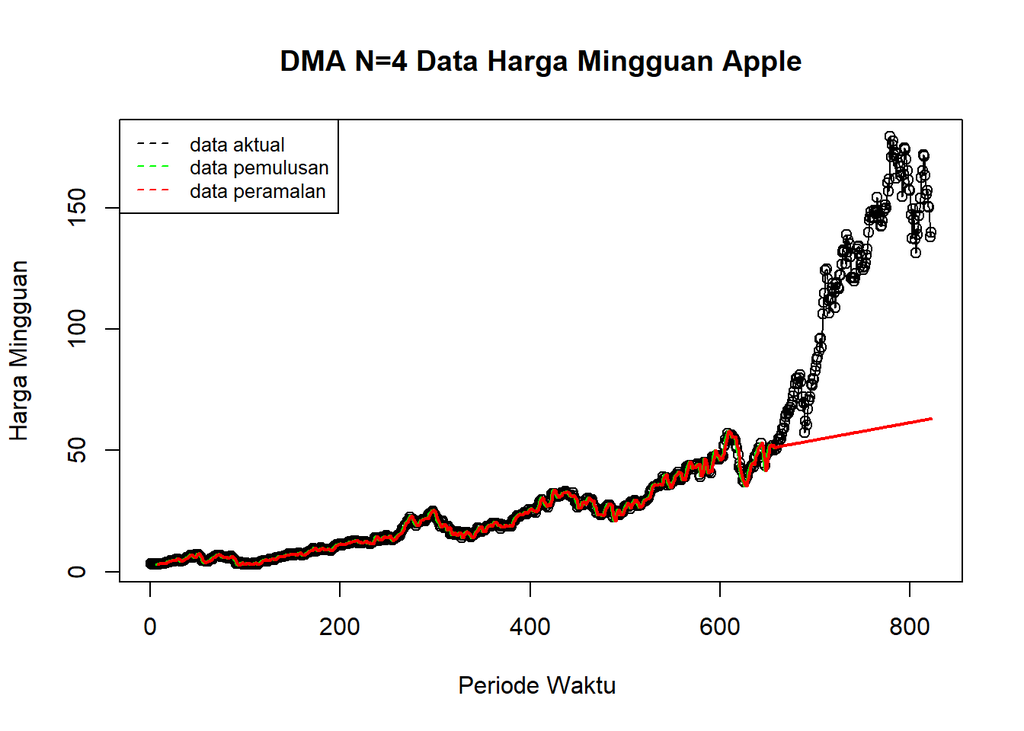

```r
ts.plot(data.ts, xlab="Periode Waktu ", ylab="Harga Mingguan", main= "DMA N=4 Data Harga Mingguan Apple")
points(data.ts)
lines(data.gab2[,3],col="green",lwd=2)
lines(data.gab2[,6],col="red",lwd=2)
legend("topleft",c("data aktual","data pemulusan","data peramalan"), lty=8, col=c("black","green","red"), cex=0.8)
```

Selanjutnya perhitungan akurasi dilakukan baik pada data train maupun data test. Perhitungan akurasi dilakukan dengan ukuran akurasi SSE, MSE dan MAPE.

```r
#Menghitung nilai keakuratan data train
error_train.dma = training.ts-data.ramal2[1:length(training.ts)]
SSE_train.dma = sum(error_train.dma[8:length(training.ts)]^2)
MSE_train.dma = mean(error_train.dma[8:length(training.ts)]^2)
MAPE_train.dma = mean(abs((error_train.dma[8:length(training.ts)]/training.ts[8:length(training.ts)])*100))

akurasi_train.dma <- matrix(c(SSE_train.dma, MSE_train.dma, MAPE_train.dma))
row.names(akurasi_train.dma)<- c("SSE", "MSE", "MAPE")
colnames(akurasi_train.dma) <- c("Akurasi m = 4")
akurasi_train.dma
```

```
##      Akurasi m = 4
## SSE     928.070329
## MSE       1.425607
## MAPE      4.362937
```

Perhitungan akurasi pada data train menggunakan nilai MAPE menghasilkan nilai MAPE yang kurang dari 10% sehingga dikategorikan sangat baik. Selanjutnya, perhitungan nilai akurasi dilakukan pada data test.

```r
#Menghitung nilai keakuratan data test
error_test.dma = test.ts-data.gab2[659:822,6]
SSE_test.dma = sum(error_test.dma^2)
MSE_test.dma = mean(error_test.dma^2)
MAPE_test.dma = mean(abs((error_test.dma/test.ts*100)))

akurasi_test.dma <- matrix(c(SSE_test.dma, MSE_test.dma, MAPE_test.dma))
row.names(akurasi_test.dma)<- c("SSE", "MSE", "MAPE")
colnames(akurasi_test.dma) <- c("Akurasi m = 4")
akurasi_test.dma
```

```
##      Akurasi m = 4
## SSE    853651.4922
## MSE      5205.1920
## MAPE       47.7258
```

Perhitungan akurasi menggunakan data test menghasilkan nilai MAPE yang lebih dari 10% sehingga nilai akurasi ini dapat dikategorikan sebagai kurang baik.

##Single Exponential Smoothing Single Exponential Smoothing merupakan metode pemulusan yang tepat digunakan untuk data dengan pola stasioner atau konstan.

Nilai pemulusan pada periode ke-t didapat dari persamaan:

$$\tilde{y}_T=\lambda y_t+(1-\lambda)\tilde{y}_{T-1}$$

Nilai parameter $\lambda$ adalah nilai antara 0 dan 1.

Nilai pemulusan periode ke-t bertindak sebagai nilai ramalan pada periode ke-$(T+\tau)$.

$$\tilde{y}_{T+\tau}(T)=\tilde{y}_T$$

Pemulusan dengan metode SES dapat dilakukan dengan dua fungsi dari *packages* berbeda, yaitu (1) fungsi `ses()` dari *packages* `forecast` dan (2) fungsi `HoltWinters` dari *packages* `stats` .

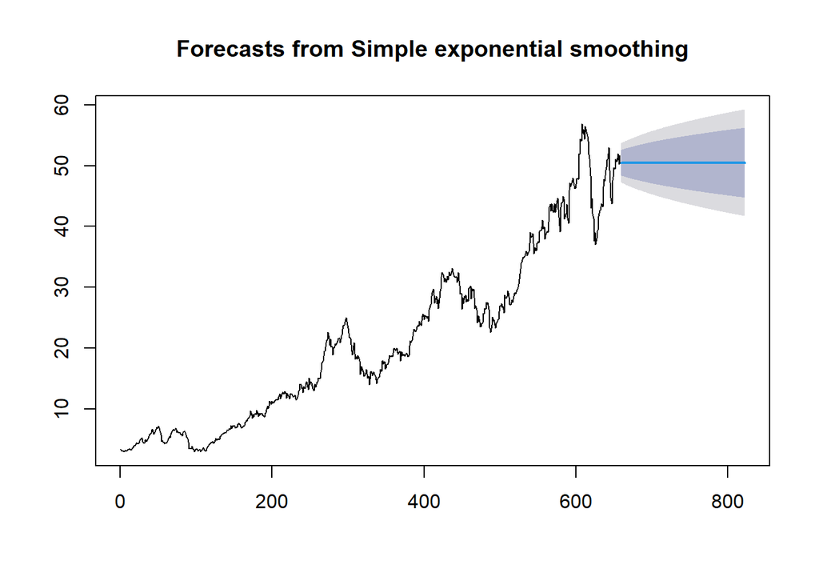

```r
#Cara 1 (fungsi ses)
ses.1 <- ses(training.ts, h = 164, alpha = 0.2)
plot(ses.1)
```

```r
ses.1
```

```
##     Point Forecast    Lo 80    Hi 80    Lo 95    Hi 95
## 659       50.47271 48.38248 52.56295 47.27598 53.66945
## 660       50.47271 48.34108 52.60434 47.21267 53.73276
## 661       50.47271 48.30048 52.64495 47.15057 53.79486
## 662       50.47271 48.26062 52.68481 47.08961 53.85582
## 663       50.47271 48.22146 52.72396 47.02972 53.91570
## 664       50.47271 48.18298 52.76245 46.97086 53.97456
## 665       50.47271 48.14513 52.80030 46.91298 54.03245
## 666       50.47271 48.10788 52.83754 46.85602 54.08941
## 667       50.47271 48.07122 52.87421 46.79994 54.14548
## 668       50.47271 48.03510 52.91032 46.74471 54.20071
## 669       50.47271 47.99952 52.94591 46.69028 54.25514
## 670       50.47271 47.96443 52.98099 46.63663 54.30879
## 671       50.47271 47.92983 53.01559 46.58372 54.36171
## 672       50.47271 47.89570 53.04972 46.53151 54.41391
```

[output cut: 150 more lines]

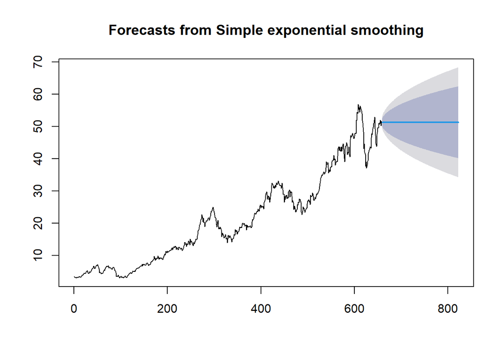

```r
ses.2<- ses(training.ts, h = 164, alpha = 0.7)
plot(ses.2)
```

```r
ses.2
```

```
##     Point Forecast    Lo 80    Hi 80    Lo 95    Hi 95
## 659       51.29484 50.05557 52.53411 49.39954 53.19014
## 660       51.29484 49.78211 52.80756 48.98133 53.60835
## 661       51.29484 49.55103 53.03865 48.62791 53.96176
## 662       51.29484 49.34717 53.24250 48.31614 54.27354
## 663       51.29484 49.16272 53.42696 48.03404 54.55564
## 664       51.29484 48.99299 53.59668 47.77447 54.81520
## 665       51.29484 48.83496 53.75472 47.53277 55.05690
## 666       51.29484 48.68647 53.90320 47.30569 55.28398
## 667       51.29484 48.54600 54.04367 47.09086 55.49882
## 668       51.29484 48.41237 54.17731 46.88648 55.70319
## 669       51.29484 48.28466 54.30502 46.69117 55.89851
## 670       51.29484 48.16215 54.42752 46.50381 56.08586
## 671       51.29484 48.04426 54.54541 46.32351 56.26616
## 672       51.29484 47.93050 54.65918 46.14952 56.44015
```

[output cut: 150 more lines]

Untuk mendapatkan gambar hasil pemulusan pada data train dengan fungsi `ses()` , perlu digunakan fungsi `autoplot()` dan `autolayer()` dari *library packages* `ggplot2` .

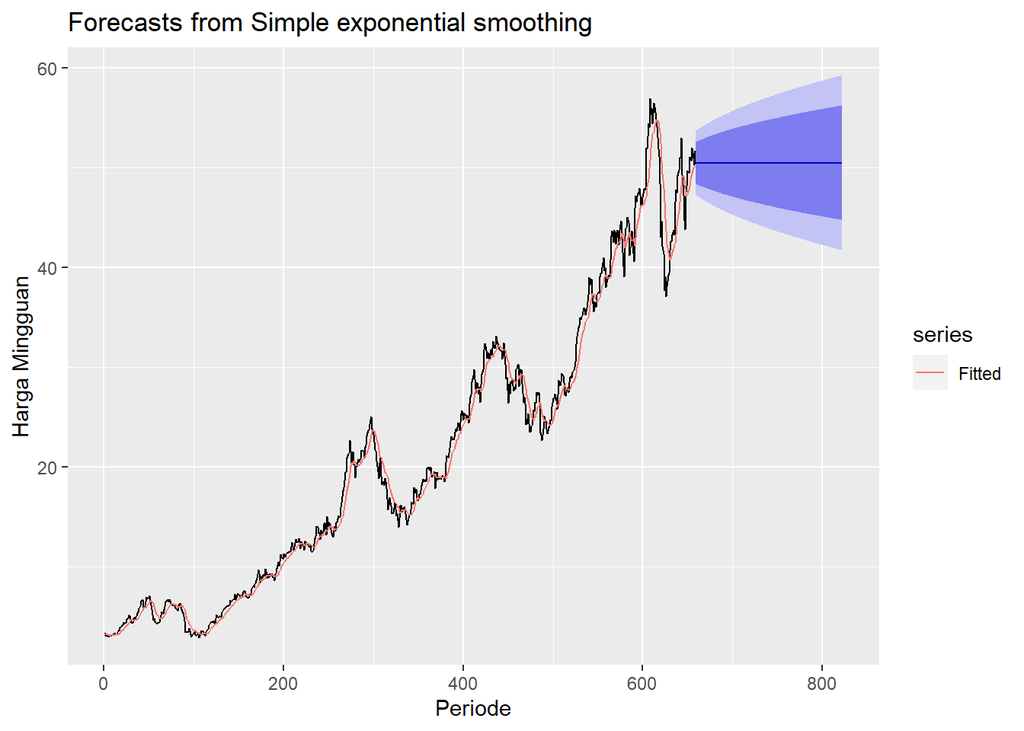

```r
autoplot(ses.1) +
  autolayer(fitted(ses.1), series="Fitted") +
  ylab("Harga Mingguan") + xlab("Periode")
```

Pada fungsi `ses()` , terdapat beberapa argumen yang umum digunakan, yaitu nilia `y` , `gamma` , `beta` , `alpha` , dan `h` .

Nilai `y` adalah nilai data deret waktu, `gamma` adalah parameter pemulusan untuk komponen musiman, `beta` adalah parameter pemulusan untuk tren, dan `alpha` adalah parameter pemulusan untuk stasioner, serta `h` adalah banyaknya periode yang akan diramalkan.

Kasus di atas merupakan contoh inisialisasi nilai parameter $\lambda$ dengan nilai `alpha` 0,2 dan 0,7 dan banyak periode data yang akan diramalkan adalah sebanyak 164 periode. Selanjutnya akan digunakan fungsi `HoltWinters()` dengan nilai inisialisasi parameter dan panjang periode peramalan yang sama dengan fungsi `ses()` .

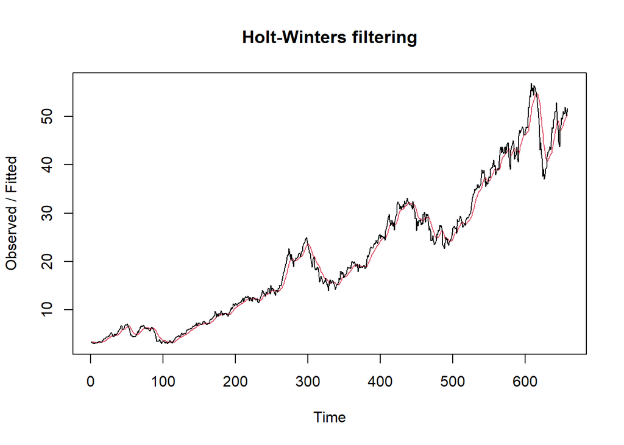

```r
#Cara 2 (fungsi Holtwinter)
ses1<- HoltWinters(training.ts, gamma = FALSE, beta = FALSE, alpha = 0.2)
plot(ses1)
```

```r
#ramalan
ramalan1<- forecast(ses1, h=164)
ramalan1
```

```
##     Point Forecast    Lo 80    Hi 80    Lo 95    Hi 95
## 659       50.47271 48.43359 52.51184 47.35414 53.59129
## 660       50.47271 48.39320 52.55222 47.29238 53.65305
## 661       50.47271 48.35359 52.59184 47.23179 53.71363
## 662       50.47271 48.31470 52.63072 47.17232 53.77310
## 663       50.47271 48.27651 52.66892 47.11390 53.83152
## 664       50.47271 48.23896 52.70646 47.05648 53.88894
## 665       50.47271 48.20204 52.74339 47.00001 53.94541
## 666       50.47271 48.16570 52.77972 46.94445 54.00098
## 667       50.47271 48.12993 52.81549 46.88974 54.05568
## 668       50.47271 48.09470 52.85072 46.83586 54.10957
## 669       50.47271 48.05998 52.88544 46.78276 54.16266
## 670       50.47271 48.02576 52.91966 46.73042 54.21500
## 671       50.47271 47.99201 52.95342 46.67880 54.26662
## 672       50.47271 47.95871 52.98672 46.62787 54.31755
```

[output cut: 150 more lines]

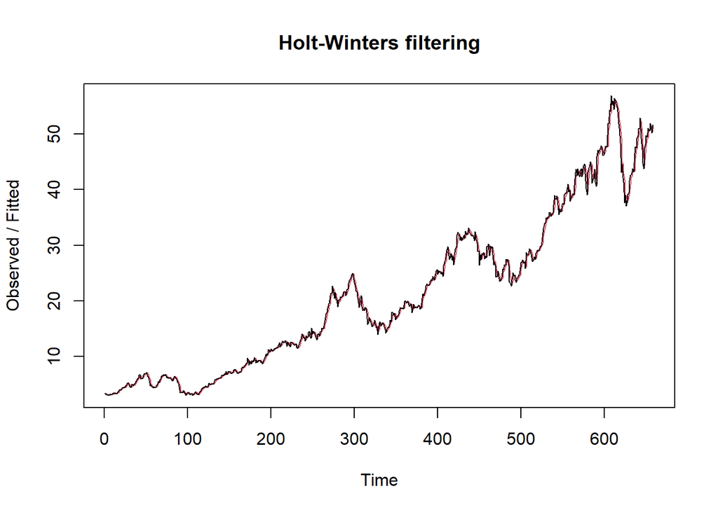

```r
ses2<- HoltWinters(training.ts, gamma = FALSE, beta = FALSE, alpha = 0.7)
plot(ses2)
```

```r
#ramalan
ramalan2<- forecast(ses2, h=164)
ramalan2
```

```
##     Point Forecast    Lo 80    Hi 80    Lo 95    Hi 95
## 659       51.29484 50.06279 52.52689 49.41058 53.17910
## 660       51.29484 49.79093 52.79875 48.99480 53.59487
## 661       51.29484 49.56119 53.02849 48.64345 53.94623
## 662       51.29484 49.35852 53.23116 48.33349 54.25619
## 663       51.29484 49.17513 53.41454 48.05303 54.53664
## 664       51.29484 49.00640 53.58327 47.79498 54.79470
## 665       51.29484 48.84928 53.74039 47.55469 55.03499
## 666       51.29484 48.70167 53.88801 47.32893 55.26075
## 667       51.29484 48.56201 54.02766 47.11534 55.47433
## 668       51.29484 48.42916 54.16052 46.91216 55.67752
## 669       51.29484 48.30219 54.28748 46.71798 55.87169
## 670       51.29484 48.18040 54.40927 46.53172 56.05796
## 671       51.29484 48.06319 54.52648 46.35247 56.23721
## 672       51.29484 47.95009 54.63958 46.17949 56.41018
```

[output cut: 150 more lines]

Fungsi `HoltWinters` memiliki argumen yang sama dengan fungsi `ses()` . Argumen-argumen kedua fungsi dapat dilihat lebih lanjut dengan `?ses()` atau `?HoltWinters` .

Nilai parameter $\alpha$ dari kedua fungsi dapat dioptimalkan menyesuaikan dari *error*-nya paling minimumnya. Caranya adalah dengan membuat parameter $\alpha =$ `NULL` .

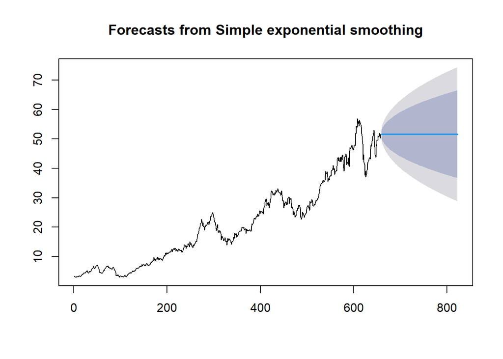

```r
#SES
ses.opt <- ses(training.ts, h = 164, alpha = NULL)
plot(ses.opt)
```

```r
ses.opt
```

```
##     Point Forecast    Lo 80    Hi 80    Lo 95    Hi 95
## 659        51.6133 50.43900 52.78761 49.81736 53.40925
## 660        51.6133 49.95966 53.26695 49.08427 54.14234
## 661        51.6133 49.59090 53.63571 48.52030 54.70630
## 662        51.6133 49.27971 53.94690 48.04437 55.18224
## 663        51.6133 49.00538 54.22122 47.62484 55.60177
## 664        51.6133 48.75729 54.46932 47.24541 55.98120
## 665        51.6133 48.52909 54.69752 46.89641 56.33020
## 666        51.6133 48.31665 54.90996 46.57150 56.65510
## 667        51.6133 48.11709 55.10952 46.26631 56.96030
## 668        51.6133 47.92833 55.29828 45.97762 57.24899
## 669        51.6133 47.74877 55.47784 45.70301 57.52360
## 670        51.6133 47.57719 55.64942 45.44061 57.78600
## 671        51.6133 47.41262 55.81399 45.18891 58.03770
## 672        51.6133 47.25425 55.97236 44.94671 58.27990
```

[output cut: 150 more lines]

```r
#Lamda Optimum Holt Winter
sesopt<- HoltWinters(training.ts, gamma = FALSE, beta = FALSE,alpha = NULL)
sesopt
```

```
## Holt-Winters exponential smoothing without trend and without seasonal component.
##
## Call:
## HoltWinters(x = training.ts, alpha = NULL, beta = FALSE, gamma = FALSE)
##
## Smoothing parameters:
##  alpha: 0.9915447
##  beta : FALSE
##  gamma: FALSE
##
## Coefficients:
##       [,1]
## a 51.61341
```

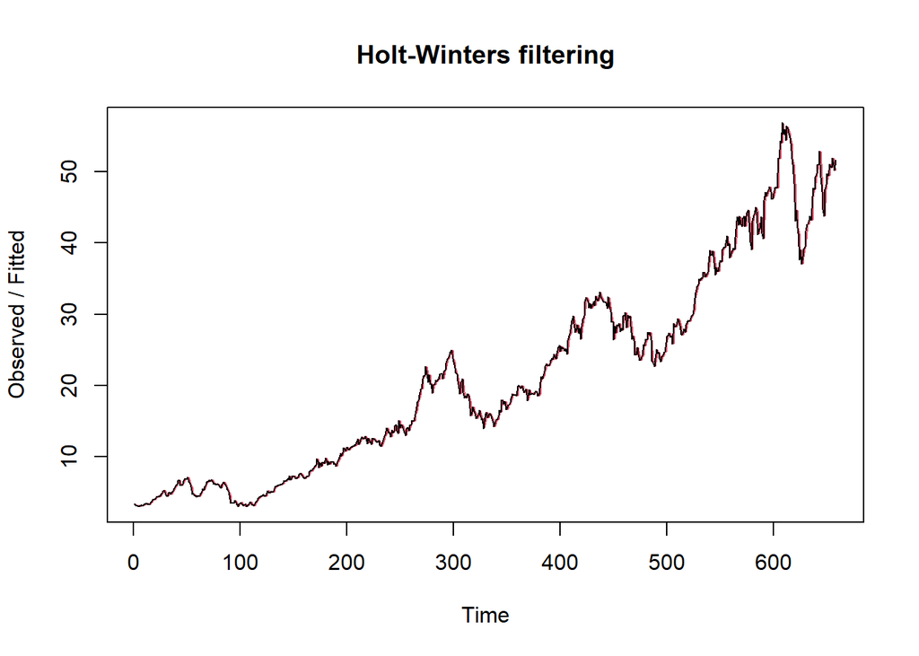

```r
plot(sesopt)
```

```r
#ramalan
ramalanopt<- forecast(sesopt, h=164)
ramalanopt
```

```
##     Point Forecast    Lo 80    Hi 80    Lo 95    Hi 95
## 659       51.61341 50.44295 52.78387 49.82335 53.40347
## 660       51.61341 49.96511 53.26170 49.09256 54.13426
## 661       51.61341 49.59752 53.62929 48.53038 54.69643
## 662       51.61341 49.28732 53.93950 48.05596 55.17085
## 663       51.61341 49.01387 54.21294 47.63776 55.58906
## 664       51.61341 48.76657 54.46025 47.25954 55.96727
## 665       51.61341 48.53909 54.68772 46.91165 56.31516
## 666       51.61341 48.32733 54.89949 46.58779 56.63903
## 667       51.61341 48.12841 55.09841 46.28356 56.94325
## 668       51.61341 47.94025 55.28657 45.99579 57.23102
## 669       51.61341 47.76126 55.46555 45.72206 57.50475
## 670       51.61341 47.59023 55.63658 45.46049 57.76632
## 671       51.61341 47.42619 55.80063 45.20960 58.01721
## 672       51.61341 47.26833 55.95849 44.96818 58.25864
```

[output cut: 150 more lines]

Setelah dilakukan peramalan, akan dilakukan perhitungan keakuratan hasil peramalan. Perhitungan akurasi ini dilakukan baik pada data train dan data test.

#### Akurasi Data train

Perhitungan akurasi data dapat dilakukan dengan cara langsung maupun manual. Secara langsung, nilai akurasi dapat diambil dari objek yang tersimpan pada hasil SES, yaitu *sum of squared errors* (SSE). Nilai akurasi lain dapat dihitung pula dari nilai SSE tersebut.

```r
#Keakuratan Metode
#Pada data training
SSE1<-ses1$SSE
MSE1<-ses1$SSE/length(training.ts)
RMSE1<-sqrt(MSE1)

akurasi1 <- matrix(c(SSE1,MSE1,RMSE1))
row.names(akurasi1)<- c("SSE", "MSE", "RMSE")
colnames(akurasi1) <- c("Akurasi lamda=0.2")
akurasi1
```

```
##      Akurasi lamda=0.2
## SSE        1745.202094
## MSE           2.652283
## RMSE          1.628583
```

```r
SSE2<-ses2$SSE
MSE2<-ses2$SSE/length(training)
RMSE2<-sqrt(MSE2)

akurasi2 <- matrix(c(SSE2,MSE2,RMSE2))
row.names(akurasi2)<- c("SSE", "MSE", "RMSE")
colnames(akurasi2) <- c("Akurasi lamda=0.7")
akurasi2
```

```
##      Akurasi lamda=0.7
## SSE          613.43497
## MSE          306.71748
## RMSE          17.51335
```

```r
#Cara Manual
fitted1<-ramalan1$fitted
sisaan1<-ramalan1$residuals
head(sisaan1)
```

```
## Time Series:
## Start = 1
## End = 6
## Frequency = 1
## [1]         NA -0.2185720 -0.2862856 -0.2515285 -0.2540798 -0.1475498
```

```r
resid1<-training$Harga_Mingguan-ramalan1$fitted
head(resid1)
```

```
## Time Series:
## Start = 1
## End = 6
## Frequency = 1
## [1]         NA -0.2185720 -0.2862856 -0.2515285 -0.2540798 -0.1475498
```

```r
#Cara Manual
SSE.1=sum(sisaan1[2:length(training.ts)]^2)
SSE.1
```

```
## [1] 1745.202
```

```r
MSE.1 = SSE.1/length(training.ts)
MSE.1
```

```
## [1] 2.652283
```

```r
MAPE.1 = sum(abs(sisaan1[2:length(training.ts)]/training.ts[2:length(training.ts)])*100)/length(training.ts)
MAPE.1
```

```
## [1] 6.143036
```

```r
akurasi.1 <- matrix(c(SSE.1,MSE.1,MAPE.1))
row.names(akurasi.1)<- c("SSE", "MSE", "MAPE")
colnames(akurasi.1) <- c("Akurasi lamda=0.2")
akurasi.1
```

```
##      Akurasi lamda=0.2
## SSE        1745.202094
## MSE           2.652283
## MAPE          6.143036
```

```r
fitted2<-ramalan2$fitted
sisaan2<-ramalan2$residuals
head(sisaan2)
```

```
## Time Series:
## Start = 1
## End = 6
## Frequency = 1
## [1]          NA -0.21857200 -0.17699960 -0.07559988 -0.07553696  0.03305291
```

```r
resid2<-training$Harga_Mingguan-ramalan2$fitted
head(resid2)
```

```
## Time Series:
## Start = 1
## End = 6
## Frequency = 1
## [1]          NA -0.21857200 -0.17699960 -0.07559988 -0.07553696  0.03305291
```

```r
SSE.2=sum(sisaan2[2:length(training.ts)]^2)
SSE.2
```

```
## [1] 613.435
```

```r
MSE.2 = SSE.2/length(training.ts)
MSE.2
```

```
## [1] 0.932272
```

```r
MAPE.2 = sum(abs(sisaan2[2:length(training.ts)]/training.ts[2:length(training.ts)])*100)/length(training.ts)
MAPE.2
```

```
## [1] 3.517536
```

```r
akurasi.2 <- matrix(c(SSE.2,MSE.2,MAPE.2))
row.names(akurasi.2)<- c("SSE", "MSE", "MAPE")
colnames(akurasi.2) <- c("Akurasi lamda=0.7")
akurasi.2
```

```
##      Akurasi lamda=0.7
## SSE         613.434965
## MSE           0.932272
## MAPE          3.517536
```

#### Akurasi Data test

Akurasi data test dapat dihitung dengan cara yang hampir sama dengan perhitungan akurasi data train.

```r
selisih1<-ramalan1$mean-testing$Harga_Mingguan
SSEtesting1<-sum(selisih1^2)
MSEtesting1<-SSEtesting1/length(testing)

selisih2<-ramalan2$mean-testing$Harga_Mingguan
SSEtesting2<-sum(selisih2^2)
MSEtesting2<-SSEtesting2/length(testing)

selisihopt<-ramalanopt$mean-testing$Harga_Mingguan
SSEtestingopt<-sum(selisihopt^2)
MSEtestingopt<-SSEtestingopt/length(testing)

akurasitesting1 <- matrix(c(SSEtesting1,SSEtesting2,SSEtestingopt))
row.names(akurasitesting1)<- c("SSE1", "SSE2", "SSEopt")
akurasitesting1
```

```
##           [,1]
## SSE1   1038814
## SSE2   1019886
## SSEopt 1012612
```

```r
akurasitesting2 <- matrix(c(MSEtesting1,MSEtesting2,MSEtestingopt))
row.names(akurasitesting2)<- c("MSE1", "MSE2", "MSEopt")
akurasitesting2
```

```
##            [,1]
## MSE1   519407.1
## MSE2   509943.2
## MSEopt 506305.8
```

Selain dengan cara di atas, perhitungan nilai akurasi dapat menggunakan fungsi `accuracy()` dari *package* `forecast` . Penggunaannya yaitu dengan menuliskan `accuracy(hasil ramalan, kondisi aktual)` . Contohnya adalah sebagai berikut.

```r
#cara lain
accuracy(ramalanopt,testing$Harga_Mingguan)
```

```
##                       ME       RMSE        MAE        MPE      MAPE        MASE
## Training set  0.07404176  0.9156171  0.6069717  0.3218239  3.281101   0.9999204
## Test set     69.46255276 78.5777381 69.4741797 51.8690904 51.892041 114.4512179
##                      ACF1
## Training set -0.007279287
## Test set               NA
```

### DES

Metode pemulusan *Double Exponential Smoothing* (DES) digunakan untuk data yang memiliki pola tren. Metode DES adalah metode semacam SES, hanya saja dilakukan dua kali, yaitu pertama untuk tahapan ‘level’ dan kedua untuk tahapan ‘tren’. Pemulusan menggunakan metode ini akan menghasilkan peramalan tidak konstan untuk periode berikutnya.

Pemulusan dengan metode DES kali ini akan menggunakan fungsi `HoltWinters()` . Jika sebelumnya nilai argumen `beta` dibuat `FALSE` , kali ini argumen tersebut akan diinisialisasi bersamaan dengan nilai `alpha` .

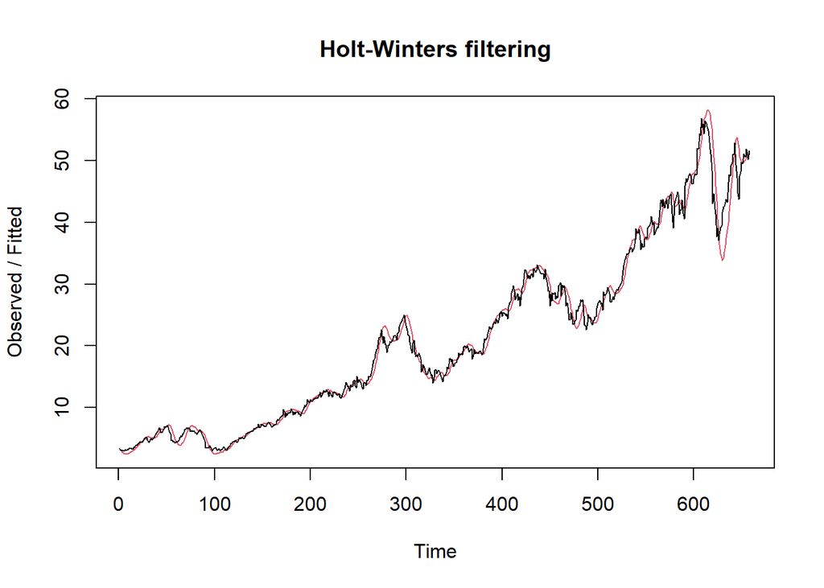

```r
#Lamda=0.2 dan gamma=0.2
des.1<- HoltWinters(training.ts, gamma = FALSE, beta = 0.2, alpha = 0.2)
plot(des.1)
```

```r
#ramalan
ramalandes1<- forecast(des.1, h=164)
ramalandes1
```

```
##     Point Forecast       Lo 80     Hi 80       Lo 95     Hi 95
## 659       51.29619  49.0760941  53.51629  47.9008450  54.69154
## 660       51.44860  49.1654559  53.73174  47.9568335  54.94036
## 661       51.60100  49.2347494  53.96726  47.9821302  55.21988
## 662       51.75341  49.2828077  54.22401  47.9749503  55.53187
## 663       51.90581  49.3091536  54.50248  47.9345643  55.87707
## 664       52.05822  49.3139057  54.80253  47.8611533  56.25529
## 665       52.21063  49.2976402  55.12361  47.7555987  56.66565
## 666       52.36303  49.2612433  55.46482  47.6192559  57.10681
## 667       52.51544  49.2057774  55.82510  47.4537494  57.57712
## 668       52.66784  49.1323751  56.20331  47.2608117  58.07487
## 669       52.82025  49.0421651  56.59833  47.0421688  58.59833
## 670       52.97265  48.9362242  57.00908  46.7994675  59.14584
## 671       53.12506  48.8155515  57.43457  46.5342359  59.71588
## 672       53.27746  48.6810569  57.87387  46.2478655  60.30706
```

[output cut: 150 more lines]

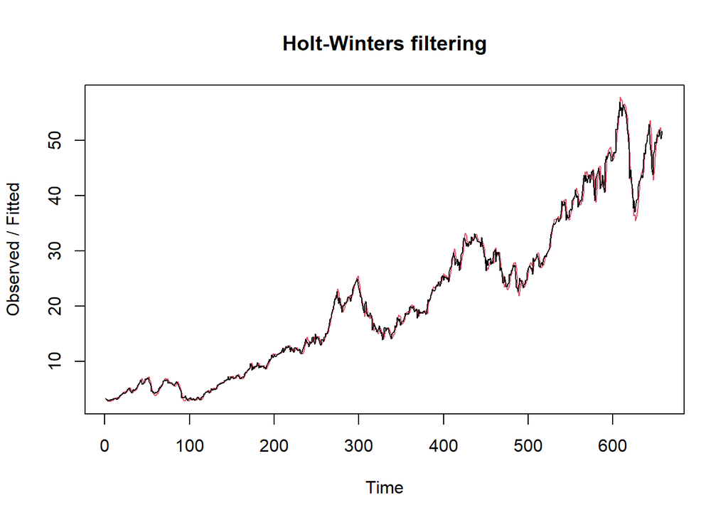

```r
#Lamda=0.6 dan gamma=0.3
des.2<- HoltWinters(training.ts, gamma = FALSE, beta = 0.3, alpha = 0.6)
plot(des.2)
```

```r
#ramalan
ramalandes2<- forecast(des.2, h=164)
ramalandes2
```

```
##     Point Forecast         Lo 80     Hi 80        Lo 95     Hi 95
## 659       51.49174   50.18656583  52.79691   49.4956493  53.48783
## 660       51.64371   49.98845965  53.29897   49.1122205  54.17521
## 661       51.79569   49.71968731  53.87170   48.6207172  54.97067
## 662       51.94767   49.39352817  54.50181   48.0414484  55.85389
## 663       52.09964   49.01877351  55.18051   47.3878591  56.81143
## 664       52.25162   48.60133526  55.90191   46.6689909  57.83425
## 665       52.40360   48.14537307  56.66182   45.8912055  58.91599
## 666       52.55557   47.65396007  57.45719   45.0592027  60.05194
## 667       52.70755   47.12946815  58.28563   44.1766100  61.23849
## 668       52.85953   46.57379624  59.14526   43.2463317  62.47272
## 669       53.01150   45.98851057  60.03450   42.2707630  63.75224
## 670       53.16348   45.37493433  60.95202   41.2519277  65.07503
## 671       53.31546   44.73420728  61.89670   40.1915688  66.43934
## 672       53.46743   44.06732670  62.86754   39.0912115  67.84365
```

[output cut: 150 more lines]

Selanjutnya jika ingin membandingkan plot data train dan data test adalah sebagai berikut.

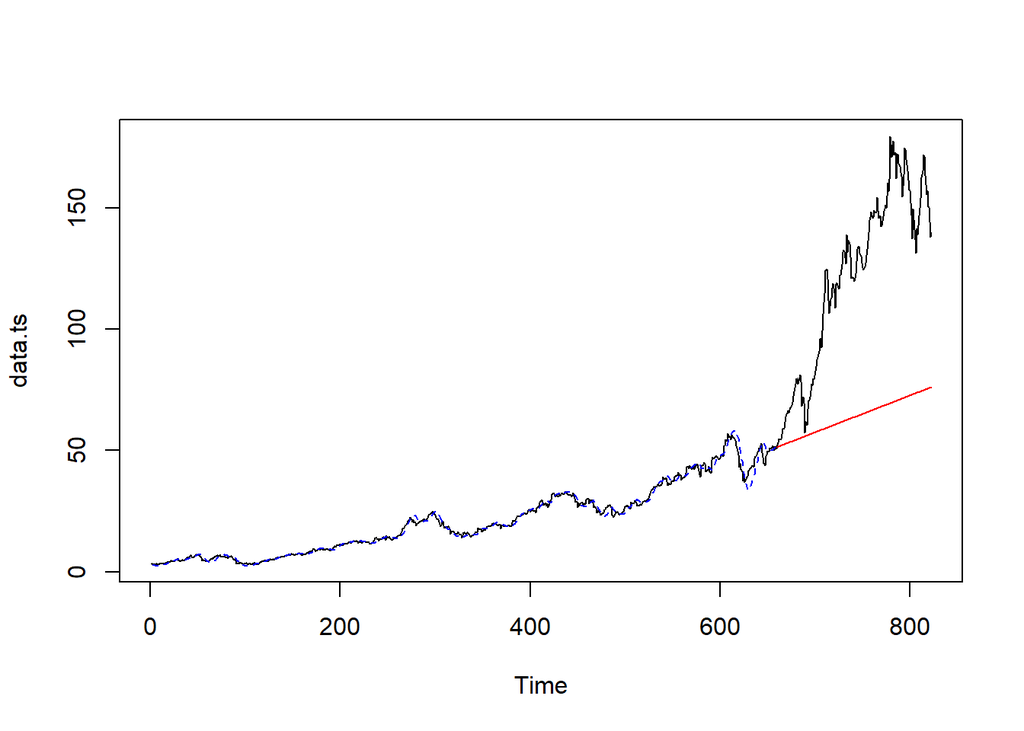

```r
#Visually evaluate the prediction
plot(data.ts)
lines(des.1$fitted[,1], lty=2, col="blue")
lines(ramalandes1$mean, col="red")
```

Untuk mendapatkan nilai parameter optimum dari DES, argumen `alpha` dan `beta` dapat dibuat `NULL` seperti berikut.

```r
#Lamda dan gamma optimum
des.opt<- HoltWinters(training.ts, gamma = FALSE)
des.opt
```

```
## Holt-Winters exponential smoothing with trend and without seasonal component.
##
## Call:
## HoltWinters(x = training.ts, gamma = FALSE)
##
## Smoothing parameters:
##  alpha: 0.9894112
##  beta : 0.009896652
##  gamma: FALSE
##
## Coefficients:
##         [,1]
## a 51.6116245
## b  0.1173454
```

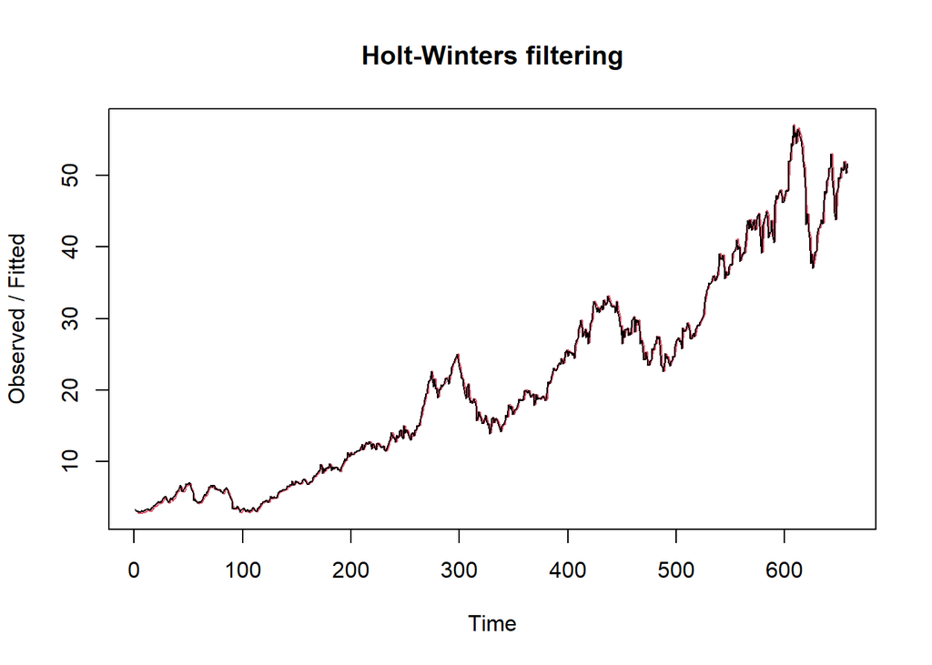

```r
plot(des.opt)
```

```r
#ramalan
ramalandesopt<- forecast(des.opt, h=164)
ramalandesopt
```

```
##     Point Forecast    Lo 80    Hi 80    Lo 95     Hi 95
## 659       51.72897 50.55160 52.90634 49.92834  53.52960
## 660       51.84632 50.18193 53.51070 49.30086  54.39177
## 661       51.96366 49.91881 54.00851 48.83633  55.09099
## 662       52.08101 49.71031 54.45170 48.45535  55.70667
## 663       52.19835 49.53626 54.86044 48.12703  56.26967
## 664       52.31570 49.38630 55.24509 47.83558  56.79582
## 665       52.43304 49.25432 55.61176 47.57161  57.29448
## 666       52.55039 49.13633 55.96444 47.32904  57.77174
## 667       52.66773 49.02958 56.30589 47.10366  58.23181
## 668       52.78508 48.93207 56.63808 46.89242  58.67774
## 669       52.90242 48.84231 56.96254 46.69302  59.11183
## 670       53.01977 48.75913 57.28041 46.50368  59.53585
## 671       53.13711 48.68161 57.59262 46.32301  59.95121
## 672       53.25446 48.60902 57.89990 46.14987  60.35905
```

[output cut: 150 more lines]

Selanjutnya akan dilakukan perhitungan akurasi pada data train maupun data test dengan ukuran akurasi SSE, MSE dan MAPE.

#### Akurasi Data train

```r
#Akurasi Data Training
ssedes.train1<-des.1$SSE
msedes.train1<-ssedes.train1/length(training.ts)
sisaandes1<-ramalandes1$residuals
head(sisaandes1)
```

```
## Time Series:
## Start = 1
## End = 6
## Frequency = 1
## [1]        NA        NA 0.1071440 0.2775014 0.3723303 0.5418712
```

```r
mapedes.train1 <- sum(abs(sisaandes1[3:length(training.ts)]/training.ts[3:length(training.ts)])
                      *100)/length(training.ts)

akurasides.1 <- matrix(c(ssedes.train1,msedes.train1,mapedes.train1))
row.names(akurasides.1)<- c("SSE", "MSE", "MAPE")
colnames(akurasides.1) <- c("Akurasi lamda=0.2 dan gamma=0.2")
akurasides.1
```

```
##      Akurasi lamda=0.2 dan gamma=0.2
## SSE                      1965.814528
## MSE                         2.987560
## MAPE                        6.079839
```

```r
ssedes.train2<-des.2$SSE
msedes.train2<-ssedes.train2/length(training.ts)
sisaandes2<-ramalandes2$residuals
head(sisaandes2)
```

```
## Time Series:
## Start = 1
## End = 6
## Frequency = 1
## [1]        NA        NA 0.1071440 0.2196437 0.1947507 0.2583094
```

```r
mapedes.train2 <- sum(abs(sisaandes2[3:length(training.ts)]/training.ts[3:length(training.ts)])
                      *100)/length(training.ts)

akurasides.2 <- matrix(c(ssedes.train2,msedes.train2,mapedes.train2))
row.names(akurasides.2)<- c("SSE", "MSE", "MAPE")
colnames(akurasides.2) <- c("Akurasi lamda=0.6 dan gamma=0.3")
akurasides.2
```

```
##      Akurasi lamda=0.6 dan gamma=0.3
## SSE                       679.374226
## MSE                         1.032484
## MAPE                        3.675509
```

Hasil akurasi dari data train didapatkan skenario 2 dengan lamda=0.6 dan gamma=0.3 memiliki hasil yang lebih baik. Namun untuk kedua skenario dapat dikategorikan peramalan sangat baik berdasarkan nilai MAPE-nya.

#### Akurasi Data test

```r
#Akurasi Data Testing
selisihdes1<-ramalandes1$mean-testing$Harga_Mingguan
selisihdes1
```

```
## Time Series:
## Start = 659
## End = 822
## Frequency = 1
##   [1]    0.6361924   -0.7364030   -1.7139954   -2.9340908   -2.5266843
##   [6]   -2.6467817   -4.5418731   -6.6894706   -6.5870640   -8.9771574
##  [11]  -11.1347538  -12.0623503  -13.3149427  -12.1675351  -13.3826296
##  [16]  -14.0952220  -15.0528164  -15.9729138  -18.4105043  -20.1655997
##  [21]  -23.2381931  -25.1857936  -24.9283840  -22.5759814  -25.0535738
##  [26]  -26.1311713  -23.0037597  -12.9288531  -16.6939516  -13.7765460
##  [31]   -1.4416414   -5.9142358   -4.1793303  -10.6719217  -14.2220151
##  [36]  -14.1121126  -15.4847090  -20.5973024  -19.8398938  -22.4824943
##  [41]  -22.0925857  -25.3301791  -27.0027706  -29.5803680  -30.4054634
##  [46]  -32.8730528  -37.6131493  -37.8682447  -34.0033381  -47.4959366
##  [51]  -52.1960320  -55.8386244  -65.1487208  -65.4338153  -61.4339057
```

[output cut: 22 more lines]

```r
SSEtestingdes1<-sum(selisihdes1^2)
MSEtestingdes1<-SSEtestingdes1/length(testing$Harga_Mingguan)
MAPEtestingdes1<-sum(abs(selisihdes1/testing$Harga_Mingguan)*100)/length(testing$Harga_Mingguan)

selisihdes2<-ramalandes2$mean-testing$Harga_Mingguan
selisihdes2
```

```
## Time Series:
## Start = 659
## End = 822
## Frequency = 1
##   [1]    0.8317383   -0.5412862   -1.5193078   -2.7398323   -2.3328549
##   [6]   -2.4533814   -4.3489020   -6.4969285   -6.3949511   -8.7854736
##  [11]  -10.9434992  -11.8715247  -13.1245463  -11.9775678  -13.1930914
##  [16]  -13.9061129  -14.8641365  -15.7846630  -18.2226826  -19.9782071
##  [21]  -23.0512297  -24.9992592  -24.7422788  -22.3903053  -24.8683269
##  [26]  -25.9463534  -22.8193710  -12.7448935  -16.5104211  -13.5934446
##  [31]   -1.2589692   -5.7319927   -3.9975163  -10.4905368  -14.0410594
##  [36]  -13.9315859  -15.3046115  -20.4176340  -19.6606545  -22.3036841
##  [41]  -21.9142046  -25.1522272  -26.8252477  -29.4032743  -30.2287988
##  [46]  -32.6968174  -37.4373429  -37.6928675  -33.8283900  -47.3214176
##  [51]  -52.0219421  -55.6649637  -64.9754892  -65.2610128  -61.2615323
```

[output cut: 22 more lines]

```r
SSEtestingdes2<-sum(selisihdes2^2)
MSEtestingdes2<-SSEtestingdes2/length(testing$Harga_Mingguan)
MAPEtestingdes2<-sum(abs(selisihdes2/testing$Harga_Mingguan)*100)/length(testing$Harga_Mingguan)

selisihdesopt<-ramalandesopt$mean-testing$Harga_Mingguan
selisihdesopt
```

```
## Time Series:
## Start = 659
## End = 822
## Frequency = 1
##   [1]    1.0689698   -0.3386858   -1.3513384   -2.6064941   -2.2341477
##   [6]   -2.3893054   -4.3194570   -6.5021146   -6.4347683   -8.8599219
##  [11]  -11.0525785  -12.0152352  -13.3028878  -12.1905404  -13.4406951
##  [16]  -14.1883477  -15.1810023  -16.1361600  -18.6088106  -20.3989662
##  [21]  -23.5066199  -25.4892805  -25.2669311  -22.9495888  -25.4622414
##  [26]  -26.5748991  -23.4825477  -13.4427013  -17.2428600  -14.3605146
##  [31]   -2.0606702   -6.5683249   -4.8684795  -11.3961311  -14.9812848
##  [36]  -14.9064424  -16.3140990  -21.4617527  -20.7394043  -23.4170649
##  [41]  -23.0622166  -26.3348702  -28.0425218  -30.6551795  -31.5153351
##  [46]  -34.0179847  -38.7931414  -39.0832970  -35.2534507  -48.7811093
##  [51]  -53.5162649  -57.1939176  -66.5390742  -66.8592288  -62.8943795
```

[output cut: 22 more lines]

```r
SSEtestingdesopt<-sum(selisihdesopt^2)
MSEtestingdesopt<-SSEtestingdesopt/length(testing$Harga_Mingguan)
MAPEtestingdesopt<-sum(abs(selisihdesopt/testing$Harga_Mingguan)*100)/length(testing$Harga_Mingguan)

akurasitestingdes <-
  matrix(c(SSEtestingdes1,MSEtestingdes1,MAPEtestingdes1,SSEtestingdes2,MSEtestingdes2,
           MAPEtestingdes2,SSEtestingdesopt,MSEtestingdesopt,MAPEtestingdesopt),
         nrow=3,ncol=3)
row.names(akurasitestingdes)<- c("SSE", "MSE", "MAPE")
colnames(akurasitestingdes) <- c("des ske1","des ske2","des opt")
akurasitestingdes
```

```
##          des ske1     des ske2      des opt
## SSE  689162.63104 686323.82686 750726.09615
## MSE    4202.21116   4184.90138   4577.59815
## MAPE     42.90184     42.75032     44.64313
```